# Data Science Capstone Project - Milestone Report

Ronald Garrick

Monday, March 16, 2015

## Set up Workspace and Gather Data

Attach all needed libraries.

```r
library(tm)
library(SnowballC)
library(koRpus)
library(wordcloud)
library(ggplot2)
library(RWeka)
```

Get a sample from the data sets and save in a separate directory. Then, create a corpus from samples.

```r
prepareData<-function(sourceFile,sampleFile,sampleSize){
  con<-file(sourceFile,"r")
  textToRead<-iconv(readLines(con,warn=FALSE),"UTF-8","UTF-8","byte")
  sampleResult<-textToRead[sample(1:length(textToRead),size=sampleSize,replace=T)]
  write(sampleResult,file=sampleFile)
  close(con)
}
setwd("C:/Users/Ronald/Desktop/Desktop Files/Coursera/Data Science/Capstone/final/repos")
prepareData(paste(getwd(),"/en_US.blogs.txt",sep=""),paste(getwd(),"/sampled/blogsample.txt",sep=""),10000)
prepareData(paste(getwd(),"/en_US.twitter.txt",sep=""),paste(getwd(),"/sampled/twittersample.txt",sep=""),10000)
prepareData(paste(getwd(),"/en_US.news.txt",sep=""),paste(getwd(),"/sampled/newssample.txt",sep=""),10000)

#Create the corpus
corpus<-Corpus(DirSource(paste(getwd(),"/sampled",sep="")), readerControl = list(language="en"))
```

Summary Statistics of Sample Data

```r
summary(corpus[[1]])
```

```
##         Length Class            Mode
## content 10000  -none-           character
## meta        7  TextDocumentMeta list
```

```r
summary(corpus[[2]])
```

```
##         Length Class            Mode
## content 10000  -none-           character
## meta        7  TextDocumentMeta list
```

```r
summary(corpus[[3]])
```

```
##         Length Class            Mode
## content 10000  -none-           character
## meta        7  TextDocumentMeta list
```

Utility functions.

```r
removeProfanity<-function(x){gsub("[^A-Za-z][Ss][Hh][Ii][Tt]e?[^A-Za-z]|[Ff][Uu][Cc][Kk]|([^A-Za-z][Aa][Ss][Ss]
              [^A-Za-z][Hh][Oo][Ll][Ee])|([Dd][Ii][Cc][Kk]([Hh][Ee][Aa][Dd])?)|[Cc][Uu][Nn][Tt]","",x)}
removeUnwantedWords<-function(x){gsub("(Ã¢â¬).|Ã¢.|~|\u009d|Ã£.","",x)}
replaceContractions<-function(x){
  x<-gsub("'ll"," will",x,perl=T)
  x<-gsub("'ve"," have",x,perl=T)
  x<-gsub("'d", " had",x,perl=T)
  x<-gsub("n't"," not",x,perl=T)
  x<-gsub("'s"," is",x,perl=T)
}

#Takes data frame and title, n number of top words, and a title and returns a bar plot.
printDescendingFrequencyBar<-function(x,n=25,title){
  x<-x[1:n,]
  x$words <- factor(x$words, levels=unique(as.character(x$words)))
  bar<-qplot(x=x$words,y=x$total,data=x,geom='bar',stat="identity")
  bar<-bar + theme(axis.text.x = element_text(angle = 90, hjust = 1,size=14,face="bold"))
  bar<-bar+xlab("Words")+ylab("Frequency")+ggtitle(title)
  bar
}

tokenizer<-function(corpus,nGrams){
  tokenizer <- function(x) {RWeka::NGramTokenizer(x, RWeka::Weka_control(min=nGrams,max=nGrams))}
  tdm<-TermDocumentMatrix(corpus,control=list(tokenize=tokenizer))
  term.matrix<-as.matrix(tdm)
  term.frame<-data.frame(term.matrix)
  rm(term.matrix)
  term.frame<-data.frame(words=row.names(term.frame),total=term.frame$Blogs+
                           term.frame$Twitter+term.frame$News)
  term.frame<-term.frame[order(-term.frame$total),]
  term.frame<-data.frame(words=term.frame$words,total=term.frame$total)
  return(term.frame)
}
```

# Preprocessing

Apply appropriate transformations to the data.

```r
corpus<-tm_map(corpus,removeProfanity) #remove profanity
corpus<-tm_map(corpus,removeUnwantedWords) #remove unwanted words
corpus<-tm_map(corpus,replaceContractions) #replace contractions with the words they represent
corpus<-tm_map(corpus,stripWhitespace)  #remove whitespace
corpus<-tm_map(corpus,tolower)  #lowercase
corpus<-tm_map(corpus,removeNumbers) #remove numbers
corpus<-tm_map(corpus,removePunctuation) #remove punctuation
corpus<-tm_map(corpus,PlainTextDocument) #re-convert to PlainTextDocument
names(corpus)<-c("Blogs","Twitter","News")
```

Create TermDocumentMatrix for 1-,2-,3-, and 4-grams.

```r
df.1g<-tokenizer(corpus,1)
df.2g<-tokenizer(corpus,2)
df.3g<-tokenizer(corpus,3)
df.4g<-tokenizer(corpus,4)
```

# Exploratory Analysis

## Groupings of Words (1-4 Grams)

The following barplots show the 10 most popular terms for singletons, 2-, 3-, and 4-grams. From this exploration, its clear that stopwords are by the far the most prevalent terms used. Since we need to predict from these common terms, they are intentionally left in our dataset.

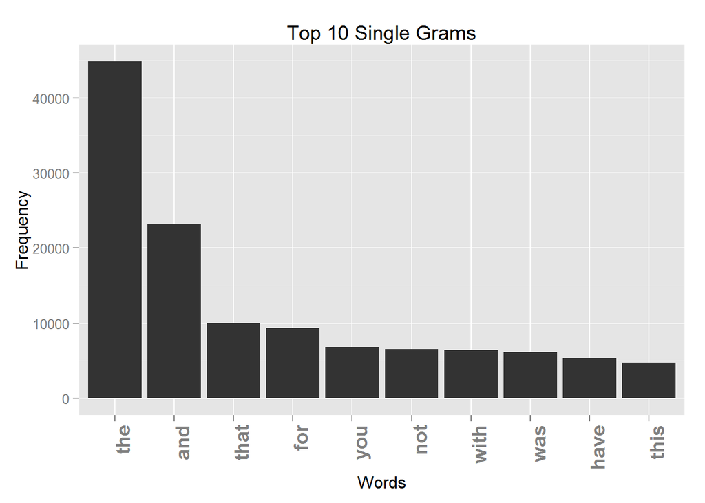

```r
printDescendingFrequencyBar(df.1g,n=10,"Top 10 Single Grams")
```

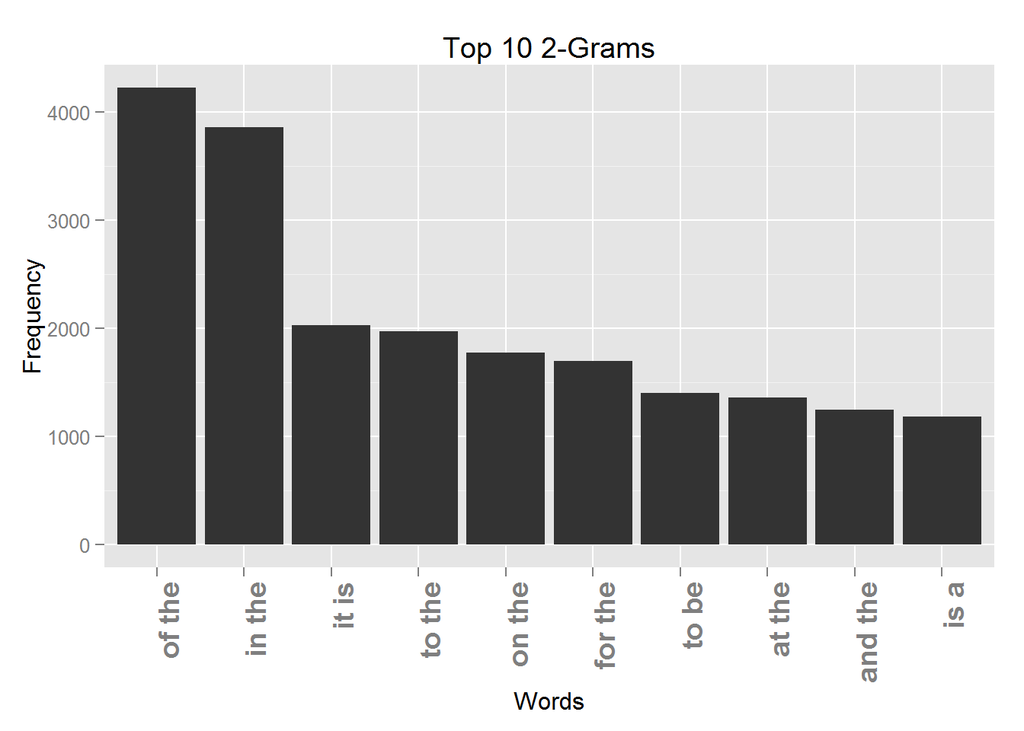

```r
printDescendingFrequencyBar(df.2g,n=10,"Top 10 2-Grams")
```

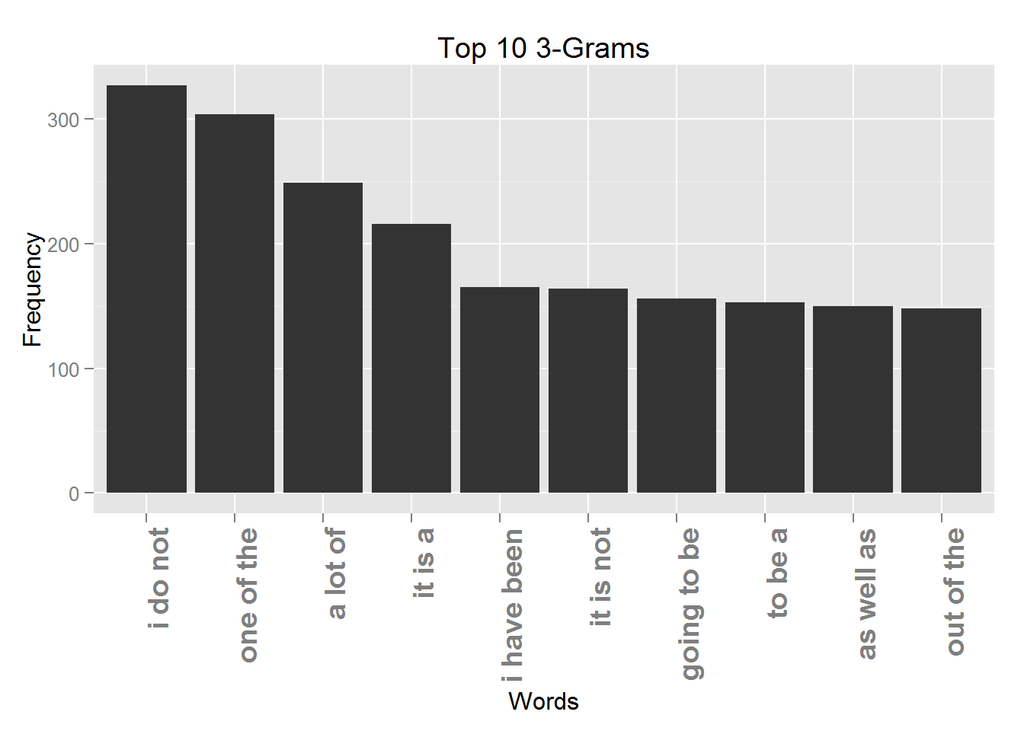

```r
printDescendingFrequencyBar(df.3g,n=10,"Top 10 3-Grams")
```

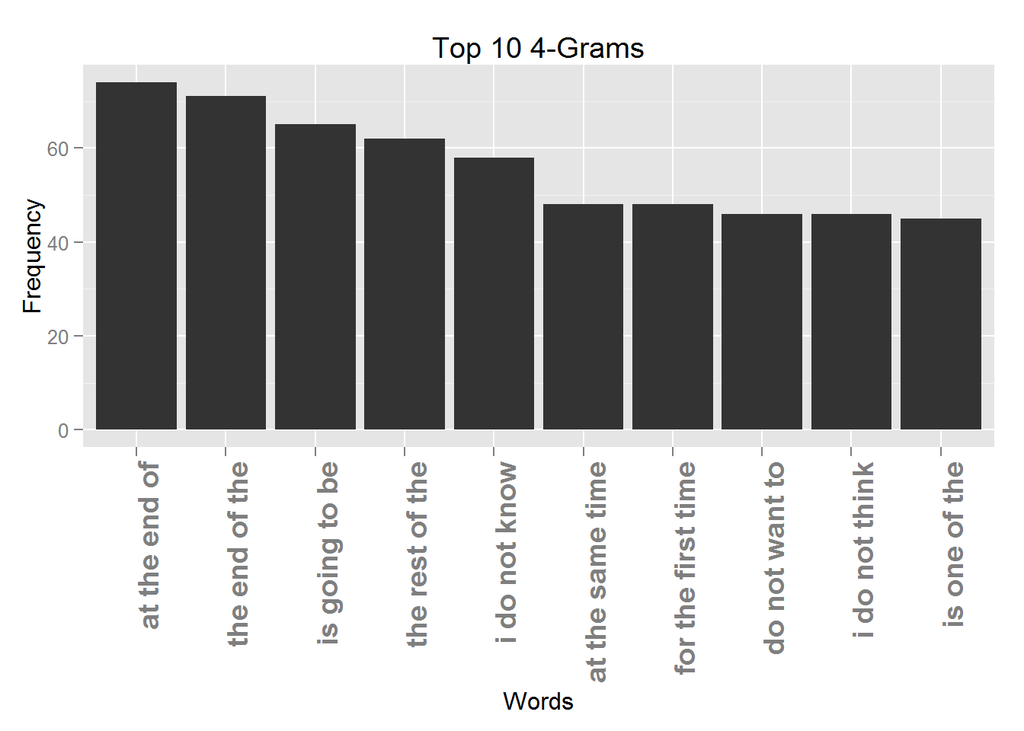

```r
printDescendingFrequencyBar(df.4g,n=10,"Top 10 4-Grams")
```

## Determine how many unique words are needed to cover 50% and 90% of all Word instances.

```r
getCoverage<-function(tf,coverage){
  df<-cbind(tf,cumperc=cumsum(tf$total)/sum(tf$total))
  x<-0;i<-1;
  while(x<coverage){
    x<-df[i,]$cumperc
    i<-i+1
  }
  return(i-1)
}
getCoverage(df.1g,0.5)
```

```
## [1] 323
```

```r
getCoverage(df.1g,0.9)
```

```
## [1] 10341
```

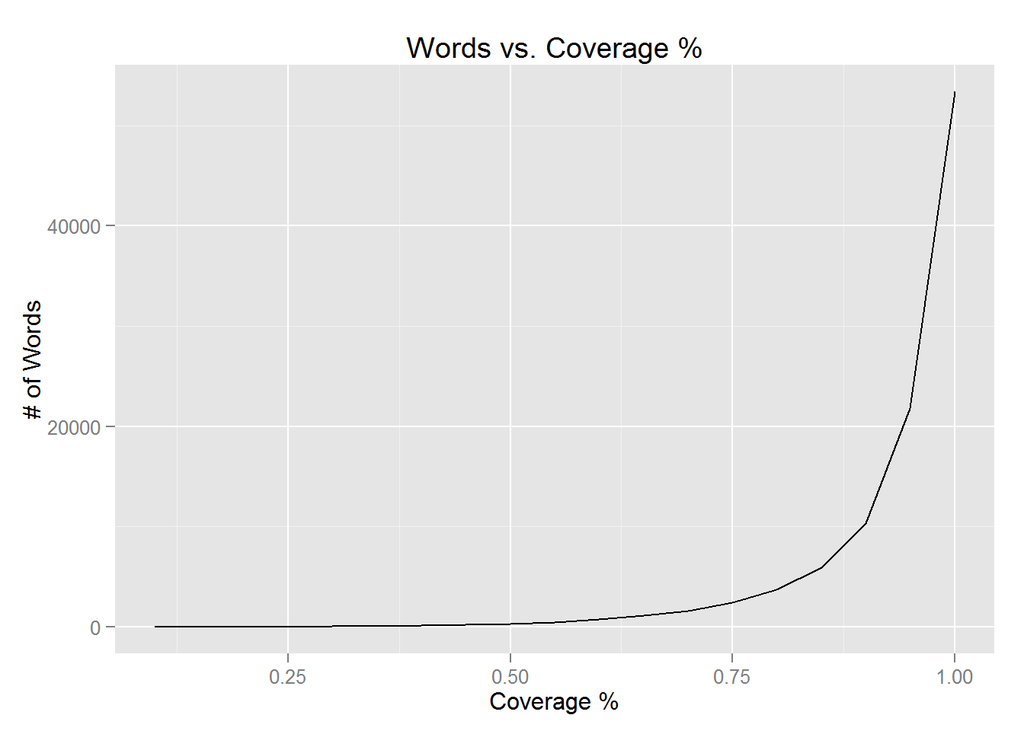

```r
plotCoverage<-function(tf,coverages){
  df<-cbind(tf,cumperc=cumsum(tf$total)/sum(tf$total))
  rows<-c()
  j=1
  switch=0
  for(i in 1:nrow(df)){
    if(df[i,]$cumperc>=coverages[j]){
      if(switch==0){
        rows[j]<-i
        j=j+1
      }
    }
  }
  return(rows)
}
#plot number of words vs. coverage percentage
x<-seq(0.1,1.0,by=0.05)
y<-plotCoverage(df.1g,x)
qplot(x,y,geom=c("line"),xlab="Coverage %",ylab="# of Words",main="Words vs. Coverage %")
```

Analyzing the # of words required for varying coverage percentages, we can see we begin to pay a very high price as we try to cover 100% of the data. This reveals it may be worthwhile to trade some coverage to reduce the size of the data set. Its likely we’ll be able to drop some unpopular words without harming the predictive power of our model.

## Lessons Learned So Far.

I’ve gained a better understanding of the tm package and other functionality built for r to support natural language processing. I’ve also gained more familiarity with handling and exploring large text-based data sets.

## Strategy for Building Predictive Model.

At this point, my intention is to build a classification model using various combination of 2-, 3-, and 4-gram term documents. If feasible, I will develop a model that uses the largest number of grams possible. So, if the user has provided 2 words, I will predict based on 2 words. If they’ve provided 3 or 4 words, I will use all 3 (or 4) words to predict. I do not intend to predict on a single word or when the prediction model provides a low level of accuracy for a given word combination.